# Problem Set #4

David Kane

2/18/2019

We will use the [polling data](https://raw.githubusercontent.com/TheUpshot/2018-live-poll-results/master/data/elections-poll-nc09-3.csv) from 3rd wave for North Carolina’s 9th Congressional District. We have distributed a copy of this data with the problem set. Make sure to use the copy we have distributed. Do *not* download it directly from the web. Make sure to read the section of the [syllabus](https://www.davidkane.info/files/gov_1005_spring_2019.html) devoted to problem sets and how to do them. NC 9 has been in the news lately . . .

## Question 2: Create (approximately) this chart

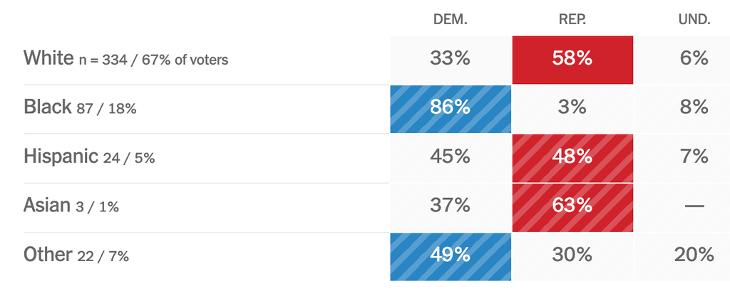

You must get the same shape (5 x 3), ordering of rows/columns and the same numerical results. But, as you saw with my example from class this week, it can be difficult to get everything to match. Morever, there are some flaws (like a lack of title and source, for example) with this plot that you should fix. The key point is that your code comments should explain, what you did and why you did it that way. If you think “DEM.” is a stupid column name, then use a better one, while explaining your reasoning in the code comments. *Hint*: The code we worked through in class is not a bad starting point, but *it will not work* out of the box. The data from NC 9 is more problematic, so you will need yo make some changes to the code. Our best advice is to examine the results at each step as you go through constructing your analysis pipeline.

## Question 3: Create (approximately) this plot

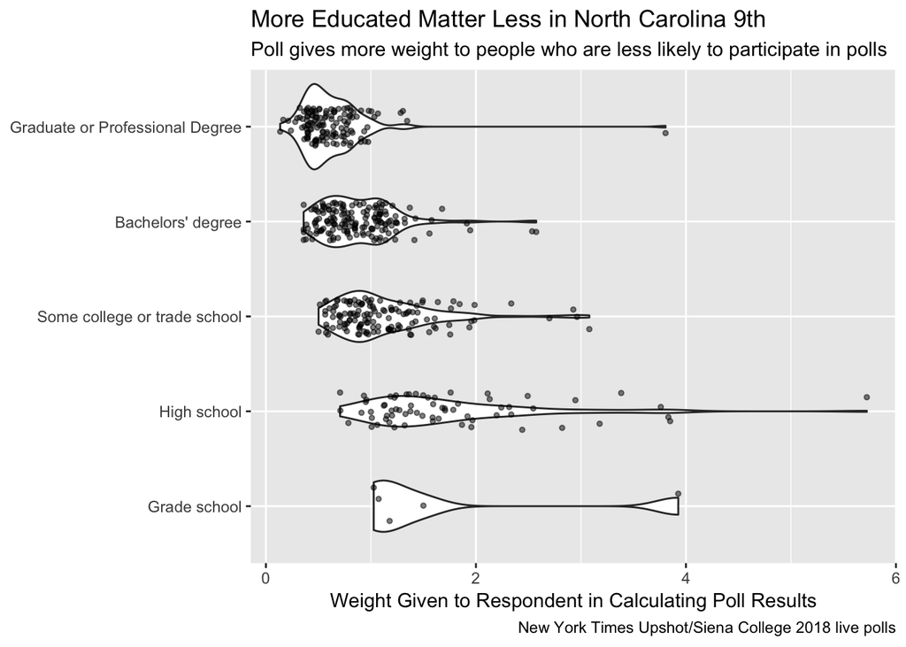

## Question 4

Look at the first few chapters of [*Data Visualization: A practical introduction*](http://socviz.co/) by Kieran Healy. It is excellent. [Chapter 5](http://socviz.co/workgeoms.html) provides several examples of how to plot categorical data. Make an interesting plot using this data, selecting the variables to use from this list: `response`, `ager`, `educ`, `file_race`, `gender`, `party_id`, `phone_type`, `genballot`, and `timestamp`. Obviously, you can’t create a plot which uses all of these variables. Indeed, most of you will just use two of them. But try to find something interesting and present it in a way of which Healy would approve. Your plot should be different from any other student’s. Make lots of comments in your code about why you made the choices you did.